```
 Last updated on 21 February, 2025
```

#### Record statistics by species and TCR chain

General statistics. Note that general statistics are computed using the ‘slim’ database version. Slim version, for example, lists the same TCR sequence found in several donors/studies only once and selects representative V/J for a given CDR3aa clonotype and the best score across all redundant records.

| Species | Chain | Records | Paired records | Unique epitopes | Studies |
| --- | --- | --- | --- | --- | --- |
| HomoSapiens | TRA | 32384 | 32384 | 1060 | 197 |
| HomoSapiens | TRB | 46962 | 27211 | 1258 | 253 |
| MacacaMulatta | TRB | 1251 | 0 | 3 | 2 |
| MusMusculus | TRA | 1636 | 1636 | 58 | 37 |
| MusMusculus | TRB | 2775 | 1598 | 80 | 41 |

#### Record statistics by year

Number of unique TCR sequences, epitopes, MHC alleles and studies by **publication** year, cumulative plots.

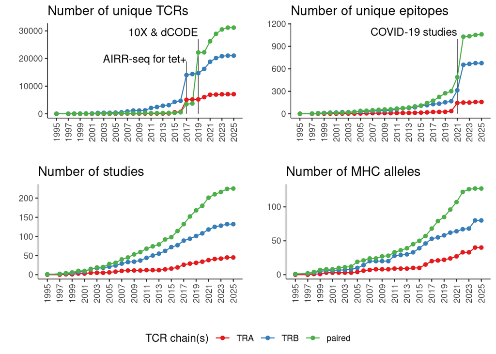

#### Summary by antigen and antigen origin

Representative data for Homo Sapiens

| Parent species | Records | Unique epitopes | Studies |
| --- | --- | --- | --- |
| CMV | 32846 | 31 | 47 |
| InfluenzaA | 11645 | 38 | 30 |
| EBV | 10626 | 33 | 37 |
| SARS-CoV-2 | 8678 | 662 | 18 |
| HomoSapiens | 7073 | 315 | 101 |
| HIV-1 | 3120 | 64 | 34 |
| HCV | 1805 | 22 | 11 |
| Mtb | 713 | 2 | 1 |
| YFV | 665 | 1 | 5 |
| DENV | 392 | 3 | 1 |
| InfluenzaB | 374 | 3 | 1 |
| PlasmodiumFalciparum | 282 | 6 | 1 |
| TriticumAestivum | 221 | 19 | 12 |
| HTLV-1 | 198 | 2 | 3 |
| SARS-CoV | 142 | 1 | 1 |
| Wheat | 82 | 2 | 3 |
| RotavirusA | 80 | 3 | 1 |
| synthetic | 62 | 29 | 4 |
| CoxsackievirusB | 59 | 2 | 1 |
| M.tuberculosis | 59 | 11 | 3 |
| HCoV-HKU1 | 45 | 1 | 1 |
| HSV-2 | 44 | 1 | 1 |
| E.Coli | 41 | 3 | 4 |
| HPV | 26 | 1 | 1 |
| gsiA | 17 | 1 | 1 |
| AdV | 15 | 2 | 1 |
| MCPyV | 12 | 2 | 1 |
| CryptomeriaJaponica | 8 | 1 | 1 |
| StreptomycesKanamyceticus | 6 | 1 | 1 |
| HPV-16 | 4 | 2 | 1 |
| HHV | 2 | 1 | 1 |
| PseudomonasAeruginosa | 2 | 1 | 1 |
| PseudomonasFluorescens | 2 | 1 | 1 |

#### **COVID-19** data

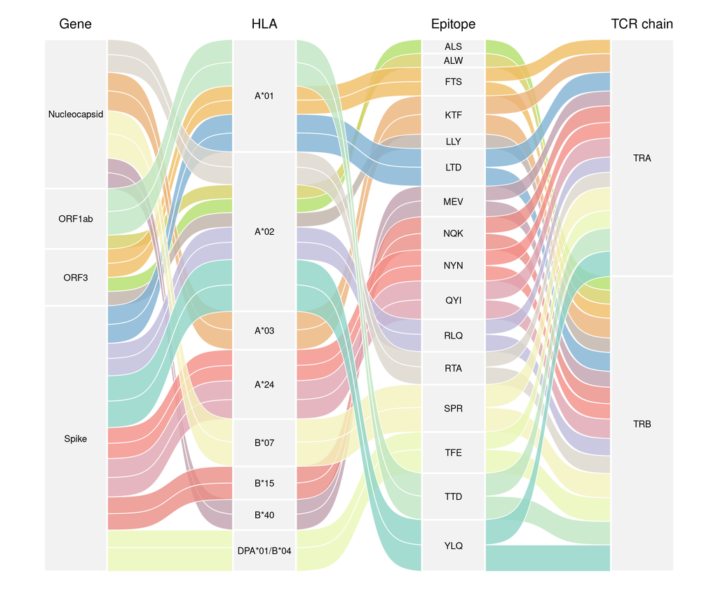

Summary of SARS-CoV-2 epitopes and corresponding TCR alpha and beta chain specificity records (cases with 10+ records)

| Gene | HLA | Epitope | Studies | TRA | TRB |
| --- | --- | --- | --- | --- | --- |
| Spike | HLA-A.02 | YLQPRTFLL | 9 | 661 | 891 |
| Nucleocapsid | HLA-B.07 | SPRWYFYYL | 4 | 370 | 520 |
| ORF1ab | HLA-A.01 | TTDPSFLGRY | 3 | 372 | 417 |
| Spike | HLA-DPA.01/B.04 | TFEYVSQPFLMDLE | 2 | 93 | 434 |
| Nucleocapsid | HLA-A.03 | KTFPPTEPK | 2 | 121 | 161 |
| Spike | HLA-A.24 | QYIKWPWYI | 5 | 130 | 144 |
| Spike | HLA-A.01 | LTDEMIAQY | 2 | 123 | 127 |
| Nucleocapsid | HLA-A.02 | RTATKQYNV | 1 | 50 | 92 |
| Spike | HLA-B.15 | NQKLIANQF | 1 | 72 | 70 |
| Spike | HLA-A.02 | RLQSLQTYV | 5 | 49 | 87 |
| Spike | HLA-A.24 | NYNYLYRLF | 3 | 56 | 52 |
| Nucleocapsid | HLA-B.40 | MEVTPSGTWL | 1 | 44 | 59 |
| ORF3 | HLA-A.01 | FTSDYYQLY | 2 | 39 | 38 |
| ORF3 | HLA-A.02 | LLYDANYFL | 3 | 27 | 40 |
| ORF1ab | HLA-A.02 | ALWEIQQVV | 2 | 27 | 36 |
| ORF3 | HLA-A.02 | ALSKGVHFV | 3 | 19 | 37 |
| ORF3 | HLA-A.24 | VYFLQSINF | 2 | 28 | 28 |
| ORF1ab | HLA-A.02 | KLWAQCVQL | 1 | 21 | 25 |
| Matrix | HLA-B.15 | RVAGDSGFAAY | 1 | 22 | 22 |
| Nucleocapsid | HLA-A.02 | RTATKAYNV | 1 | 19 | 23 |
| Matrix | HLA-B.07 | WPVTLACFV | 1 | 14 | 21 |
| ORF1ab | HLA-A.02 | KSVNITFEL | 1 | 16 | 19 |
| Spike | HLA-B.07 | SIIAYTMSL | 1 | 15 | 17 |
| ORF1ab | HLA-A.01 | PTDNYITTY | 1 | 15 | 15 |
| ORF1ab | HLA-A.02 | VMVELVAEL | 1 | 13 | 17 |
| Spike | HLA-DRA.01/B1.04 | HWFVTQRNFYEPQII | 1 | 14 | 14 |
| Matrix | HLA-A.02 | WLLWPVTLA | 1 | 9 | 16 |
| ORF14 | HLA-A.02 | LLLEWLAMA | 1 | 10 | 13 |
| Nucleocapsid | HLA-A.02 | LLLDRLNQL | 2 | 4 | 18 |
| Spike | HLA-DRA.01/B1.04 | NCTFEYVSQPFLMDL | 1 | 6 | 16 |

[output cut: 70 more lines]

#### **Self-antigen** data

Summary of T-cell receptors recognizing self-antigens, including antigens linked to utoimmune diseases and potential neoantigen targets for cancer immunotherapy. Number of records for self-antigens grouped by (mutated) human gene and corresponding HLAs are plotted using alluvium plot. Only self-antigens with at least 10 records are shown.

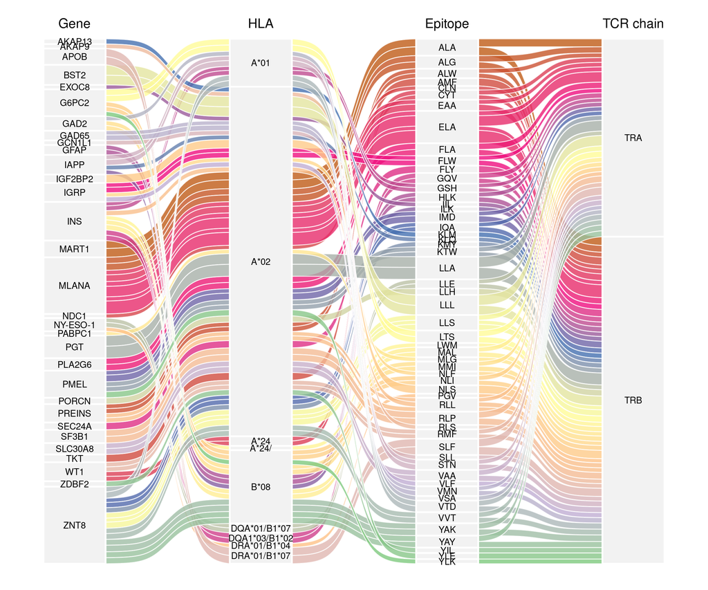

Summary of neoantigens and corresponding TCR alpha and beta chain specificity records (cases with 5+ records)

| Gene | HLA | Epitope | Studies | TRA | TRB |
| --- | --- | --- | --- | --- | --- |
| MLANA | HLA-A.02 | ELAGIGILTV | 14 | 354 | 1413 |
| PGT | HLA-A.02 | LLAGIGTVPI | 1 | 409 | 831 |
| BST2 | HLA-A.02 | LLLGIGILV | 1 | 356 | 232 |
| MART1 | HLA-A.02 | ALAGIGILTV | 1 | 90 | 144 |
| APOB | HLA-DRA.01/B1.07 | SLFFSAQPFEITAST | 1 | 95 | 103 |
| IGF2BP2 | HLA-A.02 | NLSALGIFST | 1 | 0 | 112 |
| SF3B1 | HLA-A.02 | RLPGVLPRA | 1 | 40 | 45 |
| TKT | HLA-A.02 | AMFWSVPTV | 1 | 0 | 82 |
| MLANA | HLA-A.02 | ALGIGILTV | 2 | 33 | 47 |
| G6PC2 | HLA-A.01 | LTSLTILQLY | 1 | 33 | 35 |
| PLA2G6 | HLA-A.02 | FLASKIGRLV | 1 | 34 | 34 |
| ZNT8 | HLA-B.08 | YAKWKLCSA | 1 | 27 | 40 |
| SEC24A | HLA-A.02 | FLYNLLTRV | 1 | 0 | 61 |
| ZNT8 | HLA-B.08 | YAYAKWKL | 1 | 28 | 30 |
| MLANA | HLA-A.02 | EAAGIGILTV | 6 | 13 | 43 |
| PMEL | HLA-A.02 | IMDQVPFSV | 3 | 12 | 44 |
| ZNT8 | HLA-A.01 | VTDAAHLLI | 1 | 22 | 32 |
| ZNT8 | HLA-A.02 | LLSLFSLWL | 1 | 19 | 32 |
| SLC30A8 | HLA-A.02 | VAANIVLTV | 2 | 22 | 27 |
| ZNT8 | HLA-A.02 | VVTGVLVYL | 1 | 20 | 26 |
| INS | HLA-DQA1.03/B1.02 | GQVELGGGNAVEVCK | 2 | 20 | 20 |
| IAPP | HLA-A.01 | STNVGSNTY | 1 | 14 | 25 |
| PORCN | HLA-A.02 | LLHGFSFYL | 1 | 0 | 36 |
| GAD2 | HLA-B.08 | MMIARFKM | 1 | 14 | 20 |
| GFAP | HLA-B.08 | HLKRNIVV | 1 | 13 | 21 |
| IGRP | HLA-A.02 | FLWSVFWLI | 1 | 12 | 22 |
| INS | HLA-B.08 | MALWMRLL | 1 | 15 | 19 |
| GAD65 | HLA-A.02 | VMNILLQYV | 1 | 11 | 21 |
| PMEL | HLA-A.02 | KTWGQYWQV | 1 | 16 | 16 |
| PMEL | HLA-A.02 | YLEPGPVTV | 2 | 1 | 31 |

[output cut: 106 more lines]

#### Distribution VDJdb confidence scores

Legend: 0 - low confidence, 1 - medium confidence, 2 - high confidence, 3 - very high confidence.

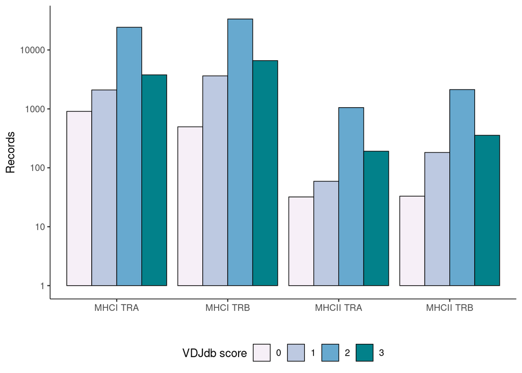

#### Spectratype

Representative data for Homo Sapiens. CDR3 length distribution (spectratype) is colored by cognate epitope. Second plot shows epitope length distribution for MHC class I and II colored by unique CDR3 (alpha or beta) records.

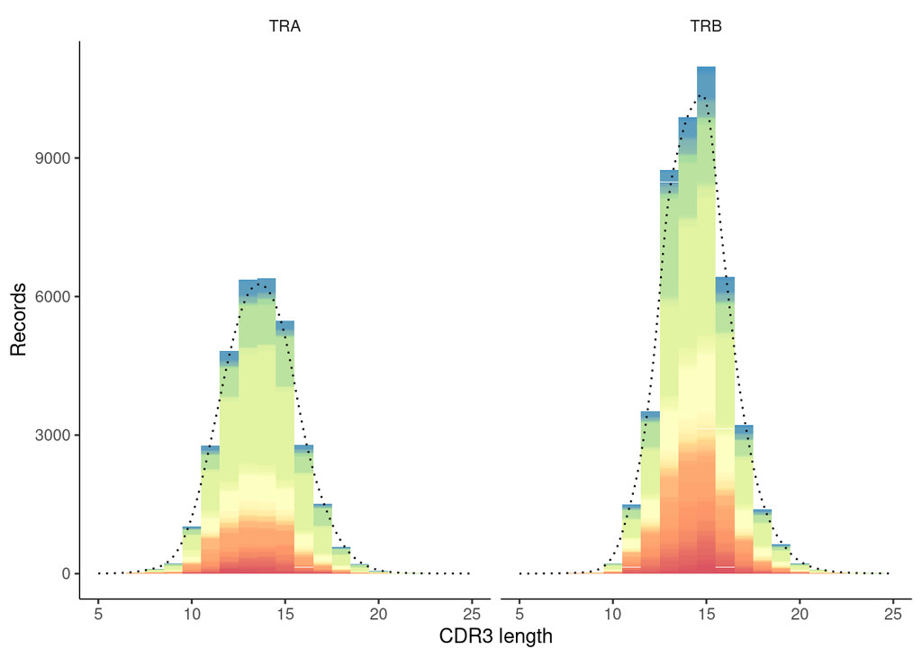

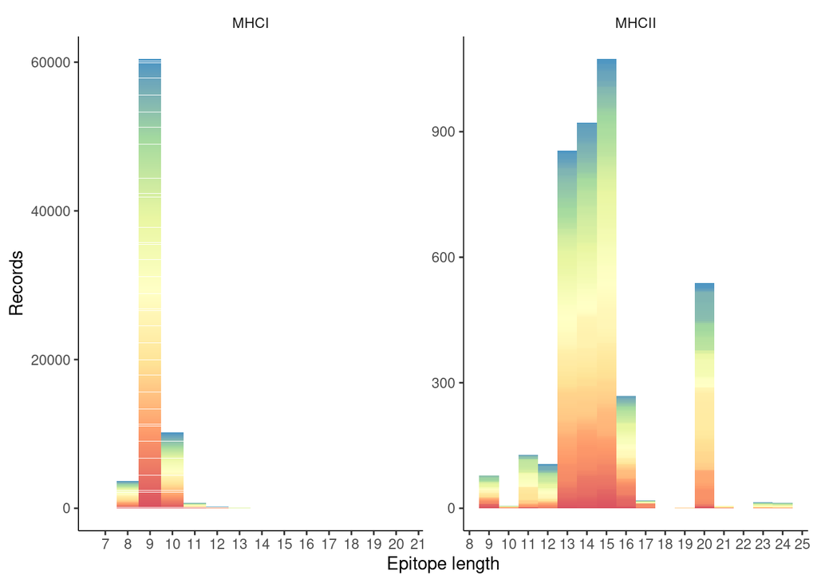

#### V(D)J usage and MHC alleles

Representative data for Homo Sapiens, Variable gene. Only Variable genes and MHC alleles with at least 10 records are shown.

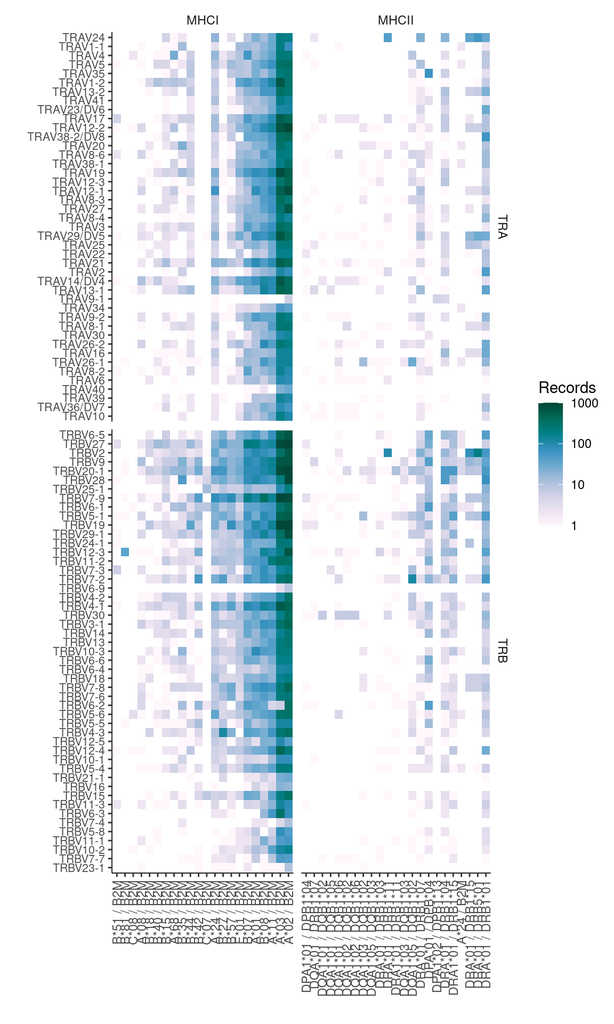

Circos plot for correspondence between human TRBV genes and MHC class I alleles for links supported by more than 50 records in terms of the ratio of observed to expected records. Band width and color (from red:highest to light yellow:lowest) are scaled proportional to co-occurrence matrix value divided by row (TRBV) and column (HLA) sums.

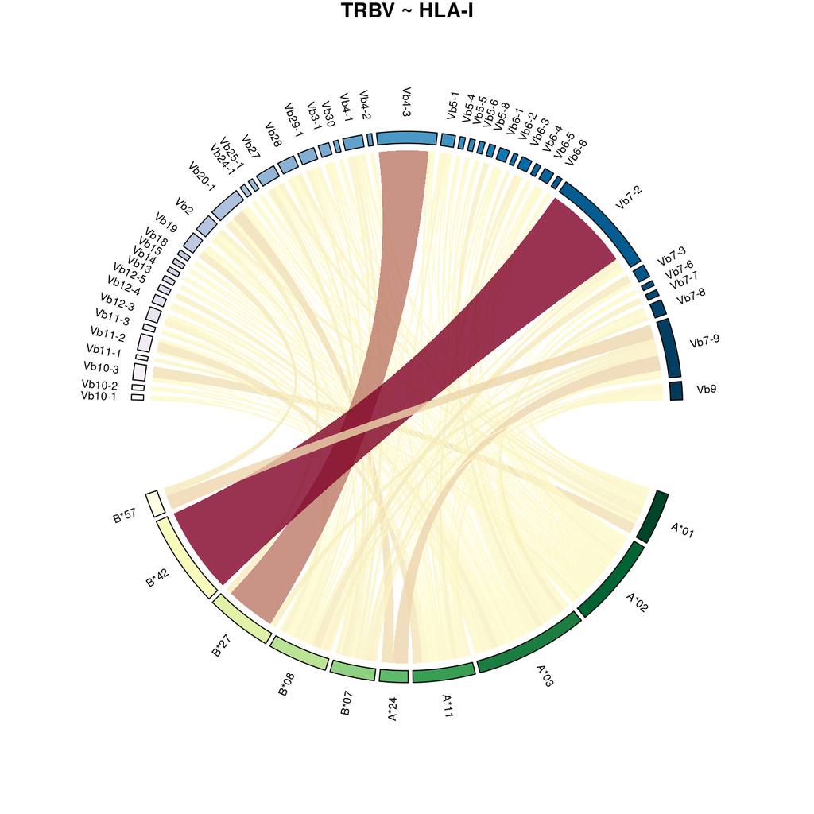

#### Detailed summary for HLA

Representative data for Homo Sapiens MHC class I and II

| First chain | Second chain | Records | Unique epitopes | Studies |
| --- | --- | --- | --- | --- |
| HLA-A*02 | B2M | 31034 | 635 | 131 |
| HLA-A*03 | B2M | 25432 | 16 | 13 |
| HLA-A*11 | B2M | 4669 | 9 | 8 |
| HLA-B*08 | B2M | 3919 | 65 | 22 |
| HLA-A*01 | B2M | 2871 | 136 | 17 |
| HLA-B*07 | B2M | 2519 | 120 | 27 |
| HLA-DRA*01 | HLA-DRB1*01 | 1238 | 15 | 12 |
| HLA-A*24 | B2M | 1007 | 73 | 16 |
| HLA-E*01 | B2M | 729 | 9 | 4 |
| HLA-B*27 | B2M | 687 | 8 | 13 |
| HLA-B*57 | B2M | 659 | 9 | 7 |
| HLA-DPA*01 | HLA-DPB*04 | 527 | 1 | 2 |
| HLA-DRA*01 | HLA-DRB1*04 | 436 | 13 | 9 |
| HLA-DRA*01 | HLA-DRB5*01 | 367 | 8 | 7 |
| HLA-B*35 | B2M | 337 | 29 | 22 |
| HLA-B*42 | B2M | 323 | 7 | 5 |
| HLA-DRA1*01 | HLA-DRB1*15 | 301 | 1 | 1 |
| HLA-DQA1*05 | HLA-DQB1*02 | 289 | 17 | 10 |
| HLA-DRA*01 | HLA-DRB1*07 | 281 | 10 | 7 |
| HLA-B*44 | B2M | 279 | 9 | 7 |
| HLA-DRA*01 | HLA-DRB1*15 | 239 | 9 | 8 |
| HLA-B*15 | B2M | 222 | 6 | 4 |
| HLA-A*68 | B2M | 210 | 4 | 4 |
| HLA-DRA*01 | HLA-DRB1*11 | 183 | 5 | 6 |
| HLA-A*08 | B2M | 117 | 1 | 1 |
| HLA-B*40 | B2M | 107 | 3 | 2 |
| HLA-B*18 | B2M | 75 | 9 | 3 |
| HLA-DQA1*03 | HLA-DQB1*02 | 58 | 8 | 3 |
| HLA-DQA1*01 | HLA-DQB1*06 | 49 | 6 | 6 |
| HLA-B*81 | B2M | 44 | 1 | 2 |
| HLA-C*07 | B2M | 43 | 3 | 2 |
| HLA-DRA*01 | HLA-DRB1*03 | 38 | 5 | 3 |
| HLA-DQA1*02 | HLA-DQB1*02 | 32 | 6 | 2 |
| HLA-DRA1*01 | HLA-DRB1*11 | 30 | 1 | 1 |
| HLA-B*51 | B2M | 29 | 1 | 1 |
| HLA-DPA1*01 | HLA-DPB1*04 | 28 | 7 | 1 |
| HLA-DQA*01 | HLA-DRB1*07 | 27 | 1 | 1 |
| HLA-DQA1*03 | HLA-DQB1*03 | 26 | 8 | 7 |
| HLA-DQA1*01 | HLA-DQB1*02 | 20 | 1 | 1 |
| HLA-DQA1*02 | HLA-DQB1*06 | 20 | 1 | 1 |
| HLA-DPA1*02 | HLA-DPB1*13 | 14 | 1 | 1 |
| HLA-DQA1*05 | HLA-DQB1*03 | 14 | 5 | 3 |
| HLA-C*08 | B2M | 10 | 3 | 3 |
| HLA-DQA1*01 | HLA-DQB1*05 | 10 | 5 | 4 |
| HLA-B*53 | B2M | 9 | 1 | 1 |
| HLA-DRA*01 | HLA-DRB3*03 | 9 | 3 | 3 |
| DPA1*02 | DPB1*05 | 8 | 1 | 1 |
| HLA-B*38 | B2M | 8 | 4 | 2 |
| HLA-A*29 | B2M | 6 | 3 | 1 |
| HLA-DPA1*02 | HLA-DPB1*01 | 6 | 3 | 1 |
| HLA-DPA1*02 | HLA-DPB1*14 | 6 | 3 | 1 |
| HLA-C*03 | B2M | 4 | 2 | 2 |
| HLA-DPA1*01 | HLA-DPB1*02 | 4 | 2 | 2 |
| HLA-DRA*01 | HLA-DRB3*02 | 4 | 1 | 1 |
| HLA-A*30 | B2M | 3 | 1 | 1 |
| HLA-DRB1*07 | HLA-DRA*01 | 3 | 1 | 1 |
| HLA-A*25 | B2M | 2 | 1 | 1 |
| HLA-B*12 | B2M | 2 | 1 | 1 |
| HLA-B*37 | B2M | 2 | 1 | 1 |
| HLA-B*58 | B2M | 2 | 1 | 1 |
| HLA-C*01 | B2M | 2 | 1 | 1 |
| HLA-C*05 | B2M | 2 | 1 | 1 |
| HLA-C*06 | B2M | 2 | 1 | 1 |
| HLA-DPA1*01 | HLA-DPB1*03 | 2 | 1 | 1 |
| HLA-DRA*01 | HLA-DRB1*09 | 2 | 1 | 1 |
| HLA-DRA*01 | HLA-DRB1*13 | 2 | 1 | 1 |
| HLA-A*32 | B2M | 1 | 1 | 1 |
| HLA-B*14 | B2M | 1 | 1 | 1 |
| HLA-B*52 | B2M | 1 | 1 | 1 |
| HLA-C*04 | B2M | 1 | 1 | 1 |